# COVID Dataset Analysis: Population Density & Cases

`August 22nd, 2025`

# Introduction

This R markdown file examines if there is a correlation between population density and the number of cases of COVID across US counties. I tested the hypothesis that population density is a predictor of cases per 100,000 residents. This was a common prediction, especially at the beginning of the pandemic and it served as a bias I wanted to examine further.

# Setting Up Required Packages

```r
# Load required libraries
library(knitr)
library(tidyverse)
library(lubridate)
library(ggplot2)
library(scales)
library(readr)
```

```r
# The below functions clean up the date formats which were giving errors
clean_date <- function(x) {
    x <- gsub("^X", "", x)
    x <- gsub("\\.", "/", x)
    x
}
```

```r
# Using read_csv from the readr package for better https support
base_url <- "https://raw.githubusercontent.com/CSSEGISandData/COVID-19/master/csse_covid_19_data/csse_covid_19_time_series/"

file_names <- c("time_series_covid19_confirmed_US.csv", "time_series_covid19_deaths_US.csv",
    "time_series_covid19_confirmed_global.csv", "time_series_covid19_deaths_global.csv")

# Downloading directly into R
covid_confirmed_us <- read_csv(paste0(base_url, file_names[1]))
covid_deaths_us <- read_csv(paste0(base_url, file_names[2]))
covid_confirmed_global <- read_csv(paste0(base_url, file_names[3]))
covid_deaths_global <- read_csv(paste0(base_url, file_names[4]))
```

# Preprocessing

```r
# Clean date columns: Confirmed US Cases Note that I am using the helper
# functions defined previously to clean the date columns.
date_cols_confirmed <- names(covid_confirmed_us)[12:ncol(covid_confirmed_us)]
date_cols_confirmed_clean <- sapply(date_cols_confirmed, clean_date, USE.NAMES = FALSE)
names(covid_confirmed_us)[12:ncol(covid_confirmed_us)] <- date_cols_confirmed_clean
date_cols_final_confirmed <- names(covid_confirmed_us)[12:ncol(covid_confirmed_us)]

# Clean date columns: US Deaths US Note that the population column is column
# #12 & dates start at 13) Also note that I am again using the helper functions
# defined previously to clean the date columns.
date_cols_deaths <- names(covid_deaths_us)[13:ncol(covid_deaths_us)]
date_cols_deaths_clean <- sapply(date_cols_deaths, clean_date, USE.NAMES = FALSE)
names(covid_deaths_us)[13:ncol(covid_deaths_us)] <- date_cols_deaths_clean
date_cols_final_deaths <- names(covid_deaths_us)[13:ncol(covid_deaths_us)]
```

```r
# Pivot confirmed cases
covid_us_confirmed_long <- covid_confirmed_us %>%
    select(UID, Admin2, Province_State, Country_Region, Lat, Long_, all_of(date_cols_final_confirmed)) %>%
    pivot_longer(cols = all_of(date_cols_final_confirmed), names_to = "date", values_to = "confirmed_cases") %>%
    mutate(date = as.Date(date, format = "%m/%d/%y"))

# Pivot deaths data Note that I am not pivoting the population
covid_us_deaths_long <- covid_deaths_us %>%
    select(UID, Admin2, Province_State, Country_Region, Lat, Long_, Population, all_of(date_cols_final_deaths)) %>%
    pivot_longer(cols = all_of(date_cols_final_deaths), names_to = "date", values_to = "deaths") %>%
    mutate(date = as.Date(date, format = "%m/%d/%y"))
```

```r
# Merge confirmed & deaths
covid_us_combined <- covid_us_confirmed_long %>%
    left_join(covid_us_deaths_long %>%
        select(UID, date, deaths, Population), by = c("UID", "date")) %>%
    arrange(UID, date)

# Calculate new cases & deaths per day
covid_us_combined <- covid_us_combined %>%
    group_by(UID) %>%
    mutate(new_cases = confirmed_cases - lag(confirmed_cases, default = 0), new_deaths = deaths -
        lag(deaths, default = 0), new_cases = pmax(new_cases, 0), new_deaths = pmax(new_deaths,
        0)) %>%
    ungroup()
```

# State-Level Analysis

## Cases Over Time by State

```r
# Calculate state population I am taking the latest available
state_pop <- covid_deaths_us %>%
    group_by(Province_State) %>%
    summarise(state_population = sum(Population, na.rm = TRUE), .groups = "drop")

# Sum cases by state and date
state_summary <- covid_us_combined %>%
    filter(!is.na(Province_State), Province_State != "") %>%
    group_by(Province_State, date) %>%
    summarise(total_cases = sum(confirmed_cases, na.rm = TRUE), .groups = "drop")

# Join state population Then calculate cases per 100k
state_summary <- state_summary %>%
    left_join(state_pop, by = "Province_State") %>%
    mutate(cases_per_100k = ifelse(state_population > 0, total_cases/state_population *
        1e+05, NA_real_)) %>%
    filter(date >= as.Date("2020-03-01") & date <= as.Date("2021-12-31"))

# Calculate top 10 states Max per-capita.
top_states <- state_summary %>%
    group_by(Province_State) %>%
    summarise(max_cases_per_100k = max(cases_per_100k, na.rm = TRUE), .groups = "drop") %>%
    filter(is.finite(max_cases_per_100k)) %>%
    top_n(10, max_cases_per_100k) %>%
    pull(Province_State)
```

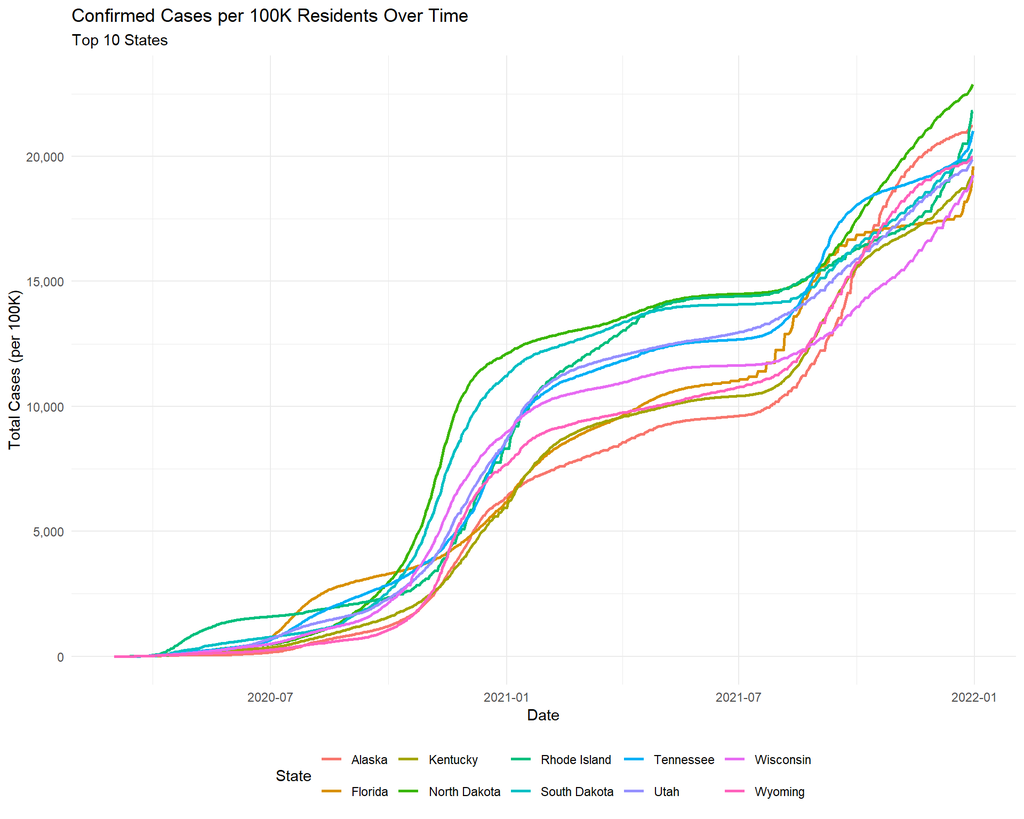

```r
# Plot top 10 states of per-capita cases

plot_cases_time <- state_summary %>%
    filter(Province_State %in% top_states) %>%
    ggplot(aes(x = date, y = cases_per_100k, color = Province_State)) + geom_line(size = 1) +
    scale_y_continuous(labels = comma_format()) + labs(title = "Confirmed Cases per 100K Residents Over Time",
    subtitle = "Top 10 States", x = "Date", y = "Total Cases (per 100K)", color = "State") +
    theme_minimal() + theme(legend.position = "bottom")

print(plot_cases_time)
```

# County-Level Analysis

## Data Preparation

```r
# County summary
latest_date <- max(covid_us_combined$date, na.rm = TRUE)
cat("Latest date in dataset:", as.character(latest_date), "\n")
```

```
## Latest date in dataset: 2023-03-09
```

```r
county_summary <- covid_us_combined %>%
    filter(date == latest_date) %>%
    filter(!is.na(Population), !is.na(confirmed_cases), !is.na(deaths)) %>%
    filter(Population > 0) %>%
    mutate(cases_per_capita = (confirmed_cases/Population) * 1e+05, deaths_per_capita = (deaths/Population) *
        1e+05) %>%
    filter(!is.na(cases_per_capita), cases_per_capita > 0)

# Print summary
cat("Data summary (Counties):\n")
```

```
## Data summary (Counties):
```

```r
cat(sprintf("Number of counties: %d\n", nrow(county_summary)))
```

```
## Number of counties: 3199
```

```r
if (nrow(county_summary) > 0) {
    cat(sprintf("Population range: %s to %s\n", format(min(county_summary$Population,
        na.rm = TRUE), big.mark = ","), format(max(county_summary$Population, na.rm = TRUE),
        big.mark = ",")))
}
```

```
## Population range: 169 to 10,039,107
```

## Population Density Categories

```r
# Chart Population Density vs COVID Cases
county_summary <- county_summary %>%
    mutate(pop_density_category = case_when(Population < 10000 ~ "Low (<10K)", Population <
        50000 ~ "Medium (10K-50K)", Population < 2e+05 ~ "High (50K-200K)", TRUE ~
        "Very High (>200K)"), pop_density_category = factor(pop_density_category,
        levels = c("Low (<10K)", "Medium (10K-50K)", "High (50K-200K)", "Very High (>200K)")))
```

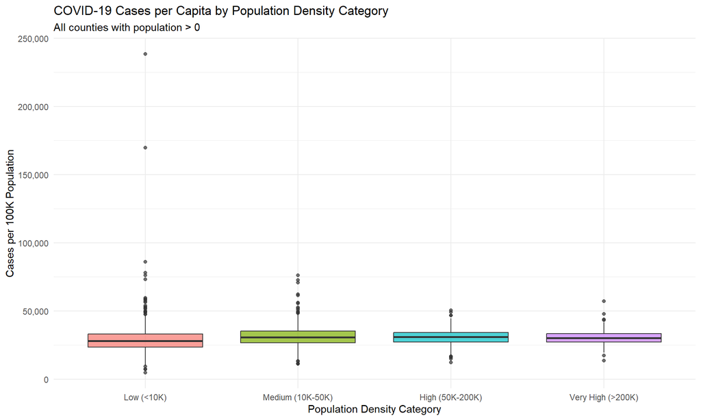

```r
plot_density_impact <- county_summary %>%
    ggplot(aes(x = pop_density_category, y = cases_per_capita, fill = pop_density_category)) +
    geom_boxplot(alpha = 0.7) + scale_y_continuous(labels = comma_format()) + labs(title = "COVID-19 Cases per Capita by Population Density Category",
    subtitle = "All counties with population > 0", x = "Population Density Category",
    y = "Cases per 100K Population", fill = "Population Category") + theme_minimal() +
    theme(legend.position = "none")

print(plot_density_impact)
```

```r
# It looks like the variation is very high for the counties with low population
# sizes This is likely because it takes very few cases to skew the per capita
# results For this reason the data will be filtered to > 5000 when I fit a
# linear model later
```

# Statistical Modeling

## Simple Linear Model: Population vs Cases per 100K

```r
# Statistical Analysis: Per Capita Cases By Population Density
model_data <- county_summary %>%
  filter(Population > 5000) %>%  # Filtering to > 5,000 residents here
  filter(!is.na(cases_per_capita), cases_per_capita > 0,
         !is.na(Population), Population > 0)

cat(sprintf("\nData for modeling (Population > 5,000): %d counties\n", nrow(model_data)))
```

```
##
## Data for modeling (Population > 5,000): 2889 counties
```

```r
if(nrow(model_data) > 0) {
  cat(sprintf("Population range for model: %s to %s\n",
              format(min(model_data$Population, na.rm = TRUE), big.mark = ","),
              format(max(model_data$Population, na.rm = TRUE), big.mark = ",")))
}
```

```
## Population range for model: 5,003 to 10,039,107
```

```r
if (nrow(model_data) > 0 && all(is.finite(model_data$cases_per_capita))) {
    # Create LM
    simple_model <- lm(cases_per_capita ~ Population, data = model_data)

    print("Linear Model Summary: Cases per 100,000")
    print(summary(simple_model))

    # Calculate R^2 & RSME
    r_squared <- summary(simple_model)$r.squared
    rmse <- sqrt(mean(simple_model$residuals^2))
    cat(sprintf("R-squared: %.4f\n", r_squared))
    cat(sprintf("RMSE: %.2f\n", rmse))

    # Add predictions to data
    model_data <- model_data %>%
        mutate(predicted_cases = predict(simple_model))
}
```

```
## [1] "Linear Model Summary: Cases per 100,000"
##
## Call:
## lm(formula = cases_per_capita ~ Population, data = model_data)
##
## Residuals:
##    Min     1Q Median     3Q    Max
## -19634  -4195   -290   3717  45326
##
## Coefficients:
##              Estimate Std. Error t value Pr(>|t|)
## (Intercept) 3.081e+04  1.272e+02 242.200   <2e-16 ***
## Population  1.404e-04  3.489e-04   0.403    0.687
## ---
## Signif. codes:  0 '***' 0.001 '**' 0.01 '*' 0.05 '.' 0.1 ' ' 1
##
## Residual standard error: 6491 on 2887 degrees of freedom
## Multiple R-squared:  5.613e-05,  Adjusted R-squared:  -0.0002902
## F-statistic: 0.1621 on 1 and 2887 DF,  p-value: 0.6873
##
## R-squared: 0.0001
## RMSE: 6489.14
```

## Model Visualization

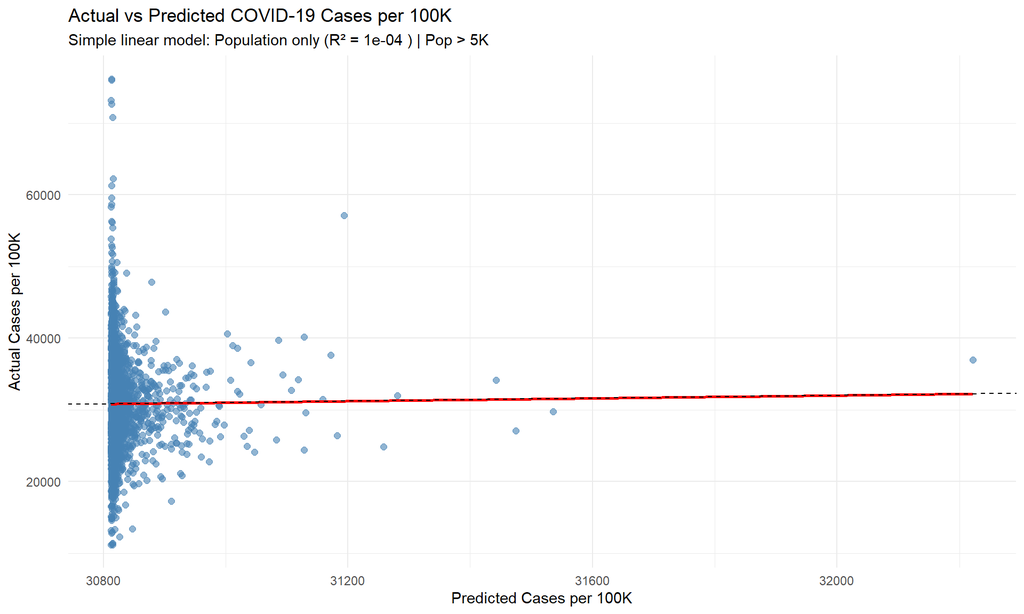

```r
if (exists("simple_model")) {
    # Visualization 3: Actual vs Predicted Cases - Simple Model
    plot_simple_model <- model_data %>%
        ggplot(aes(x = predicted_cases, y = cases_per_capita)) + geom_point(alpha = 0.6,
        color = "steelblue", size = 2) + geom_smooth(method = "lm", se = FALSE, color = "red",
        size = 1) + geom_abline(intercept = 0, slope = 1, linetype = "dashed", color = "black") +
        labs(title = "Actual vs Predicted COVID-19 Cases per 100K", subtitle = paste("Simple linear model: Population only (R² =",
            round(r_squared, 4), ") | Pop > 5K"), x = "Predicted Cases per 100K",
            y = "Actual Cases per 100K") + theme_minimal()

    print(plot_simple_model)
}
```

## Model Results and Predictions

```r
if (exists("simple_model")) {
    # Print model equation & example predictions
    intercept <- coef(simple_model)[1]
    slope <- coef(simple_model)[2]
    cat(sprintf("\nModel Equation: Cases per 100K = %.2f + %.6f × Population\n",
        intercept, slope))

    cat("\nExample Predictions:\n")
    example_pops <- c(50000, 1e+05, 250000, 5e+05)
    for (pop in example_pops) {
        pred <- intercept + slope * pop
        cat(sprintf("  Population %s: %.0f cases per 100K\n", format(pop, big.mark = ","),
            pred))
    }
}
```

```
##
## Model Equation: Cases per 100K = 30812.19 + 0.000140 × Population
##
## Example Predictions:
##   Population 50,000: 30819 cases per 100K
##   Population 1e+05: 30826 cases per 100K
##   Population 250,000: 30847 cases per 100K
##   Population 5e+05: 30882 cases per 100K
```

# Conclusions

The goal was to see if there was a relationship between population size and per capita cases. The most important statistic to look at here is the slope. Looking at the very small value for the slope (1.404489e-04) we can see that population size of a county had almost no effect on the per capita cases in the end. This can also be seen in the box plot as there was very little difference in the mean number of cases as the counties grew in size. Finally, changing the inputs of the prediction model did not lead to large swings in the outputs of the model.

This goes against the claim that densely populated cities were more likely to spread covid on a per capita basis. This is likely because given the highly contagious nature of covid, everyone eventually ended up catching it at some point, regardless of if they lived in a city or a remote area.

References: Assistance provided by Claude 4.5 Sonnet for generating code for charts, troubleshooting R Markdown knitting errors and fixing dataset connection issues, January 14, 2026.